# Assignment 6: Visualization - Aesthetic Mapping

*How to do it?*:

- Open the Rmarkdown file of this assignment (link) in Rstudio.
- Right under each **question**, insert a code chunk (you can use the hotkey `Ctrl + Alt + I` to add a code chunk) and code the solution for the question.
- `Knit` the rmarkdown file (hotkey: `Ctrl + Alt + K`) to export an html.
- Publish the html file to your Githiub Page.

*Submission*: Submit the link on Github of the assignment to Canvas.

### Questions on Your Selected Data

Choose a dataset and produce the following types of plots and comment on each plot. Plots should be meaningful. If you use the data we used in class, make sure the plots are not the same as the ones in the slides.

```r
library(tidyverse)
library(dplyr)
df <- read.csv("titanic.csv")
colnames(df)
```

```
##  [1] "PassengerId" "Survived"    "Pclass"      "Name"        "Sex"
##  [6] "Age"         "SibSp"       "Parch"       "Ticket"      "Fare"
## [11] "Cabin"       "Embarked"
```

```r
size_sum(df)
```

```
## [1] "[891 × 12]"
```

1. For one continuous variable:
- Density

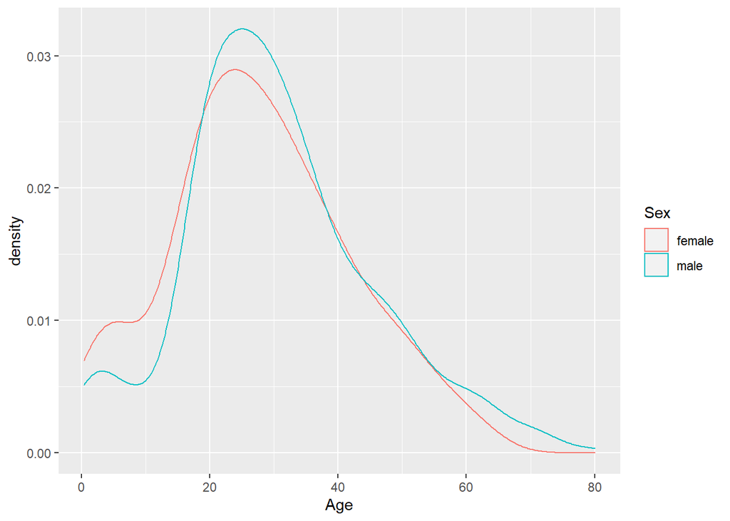

```r
ggplot(df, aes(x=Age, color=Sex)) +
  geom_density()
```

Comment: This plot is showing the density of age in the titanic data set based on sex.

- Histogram

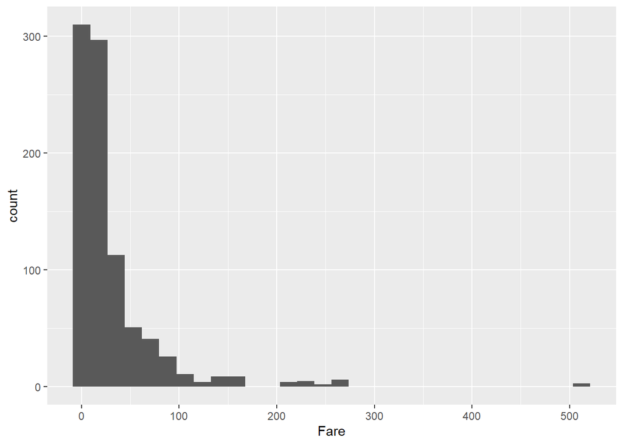

```r
ggplot(df, aes(x=Fare)) +
  geom_histogram()
```

Comment: This histogram is showing the distribution of the Fare variable in the titanic data set, which is representing how much each passenger paid for their ticket.

- Boxplot

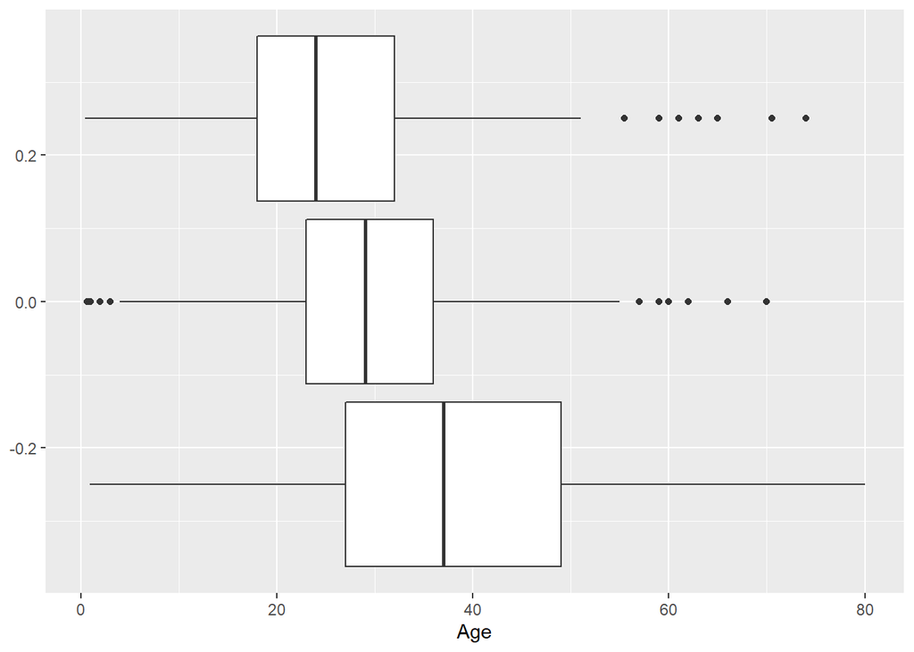

```r
ggplot(df, aes(x=Age, group = Pclass)) +
  geom_boxplot()
```

Comment: This boxplot is showing the distribution of age broken up by the passengers’ ticket class.

2. For one categorical variable
- Barplot

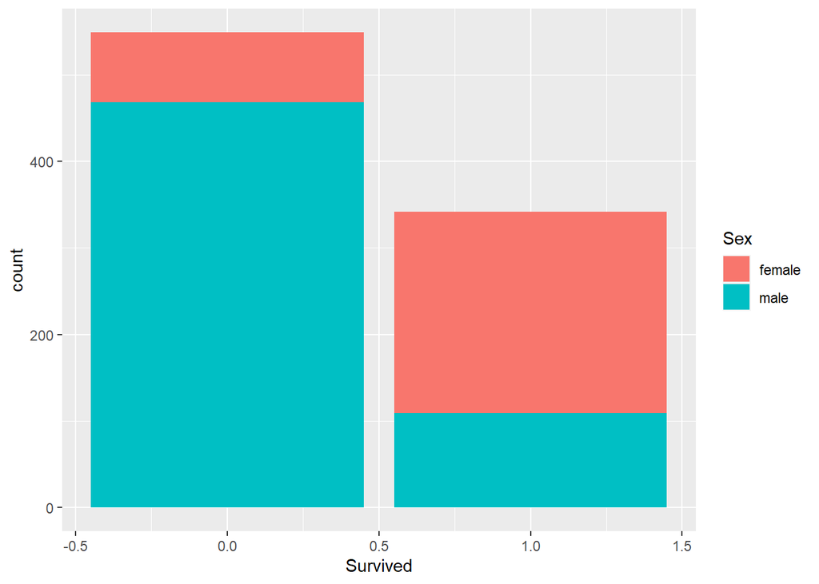

```r
ggplot(df, aes(x=Survived, fill = Sex), position = 'fill') +
  geom_bar()
```

Comment: This bar plot is showing the proportion of passengers that survived (right) and did not survive (left). The colors are showing the differences between males and females within this proportion.

3. For two continuous variables
- Scatter Plot

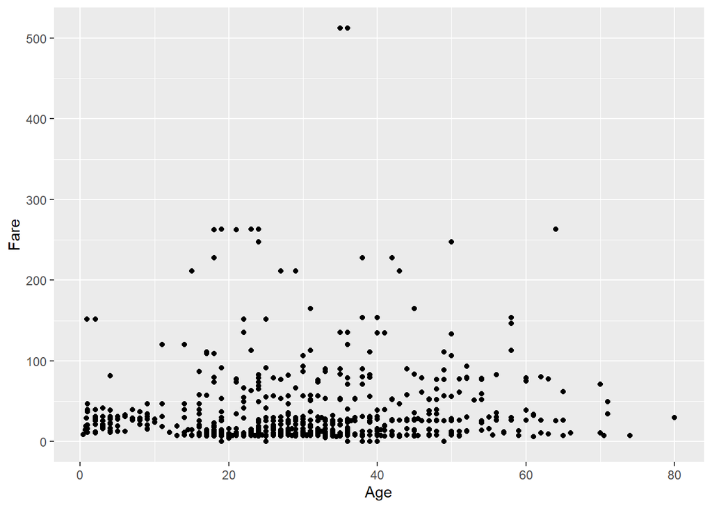

```r
ggplot(df, aes(x=Age, y = Fare)) +
  geom_point()
```

Comment: This scatterplot is showing the relationship between the age of the passengers and the amount they paid for their ticket. These two variables are realistically the only two continuous numerical variables to be used for these plots. - Line Plot

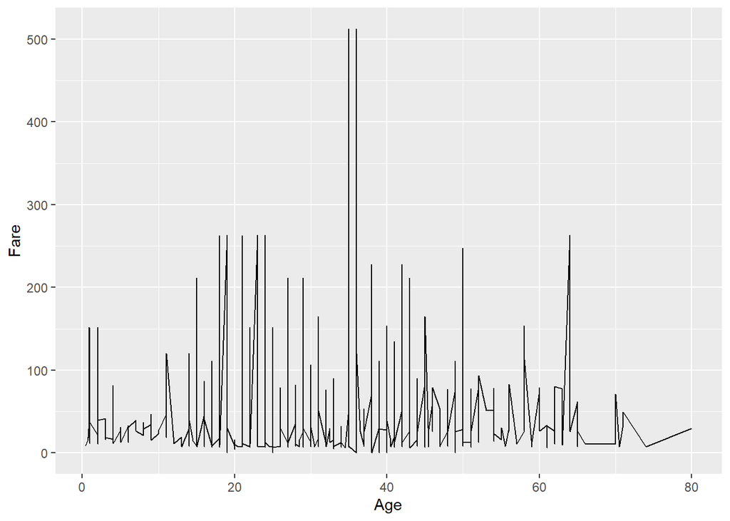

```r
ggplot(df, aes(x=Age, y = Fare)) +
  geom_line()
```

Comment: Similarly, this is also showing the relationship between age and fare.

- Smooth Plot

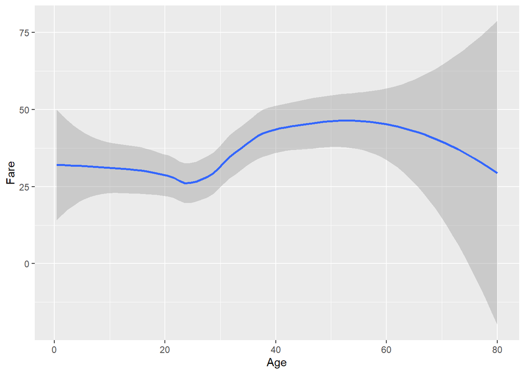

```r
ggplot(df, aes(x=Age, y = Fare)) +
  geom_smooth()
```

Comment: Once again, this is showing a relationship between age and fare, but this type of plot makes the graph easier to read.

4. For one continuous + one categorical variables
- Density

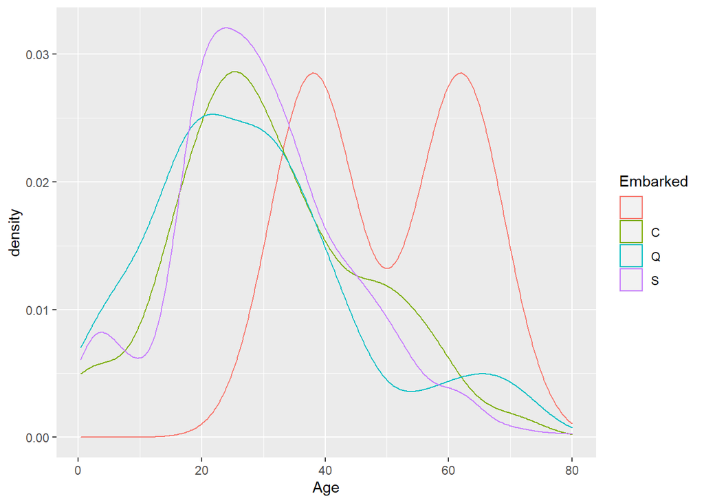

```r
ggplot(df, aes(x=Age, color = Embarked)) +
  geom_density()
```

Comment: This density plot is showing the density of ages in the dataset with relation to the embark variable.

- BoxPlot

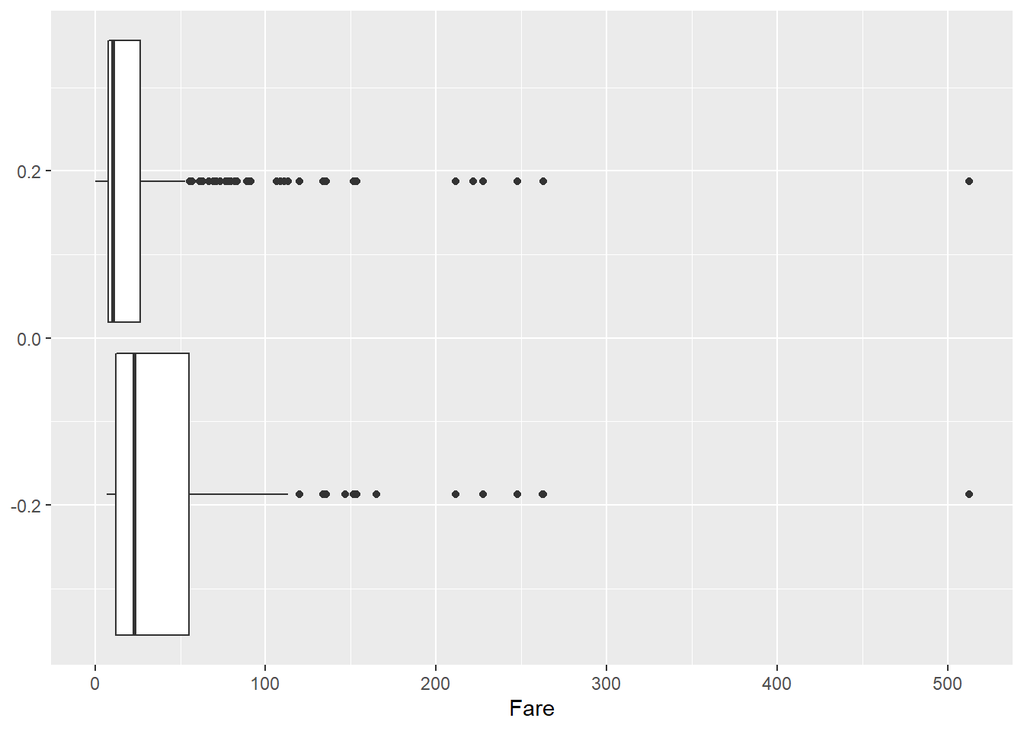

```r
ggplot(df, aes(x=Fare, group = Sex)) +
  geom_boxplot()
```

Comment: This boxpolt is showing the distribution of fare based on the sex of each passenger. There appear to be many outliers in this right-skewed data.

5. For two categorical variables: barplot

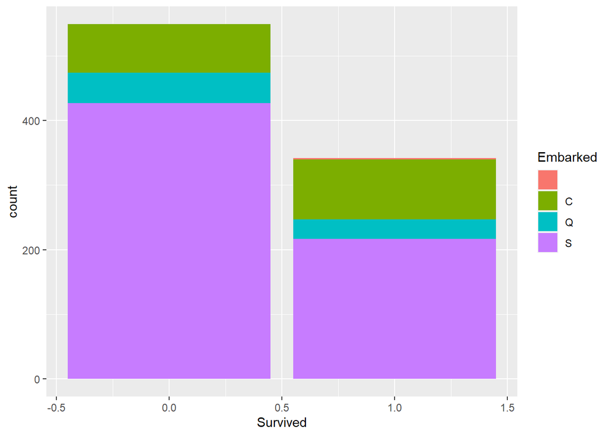

```r
ggplot(df, aes(x=Survived, fill = Embarked), position = 'fill') +
  geom_bar()
```

Comment: This bar chart is showing the proportion of passengers who survived and did not survive. The different colors in the chart represent the proportions for the embark variable.

6. A plot that contains three variables

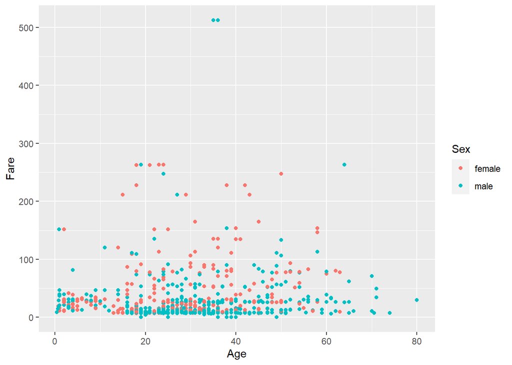

```r
ggplot(df, aes(x=Age, y = Fare, color=Sex)) +
  geom_point()
```

Comment: This scatterplot is the same one that was used earlier, except now there are two colors that differentiate between the two sexes.